# The Office

Import Data

```r
office_ratings <- readr::read_csv('https://raw.githubusercontent.com/rfordatascience/tidytuesday/master/data/2020/2020-03-17/office_ratings.csv')
episode_text <- schrute::theoffice
episode_dir_writer <- episode_text[,2:6]
```

Clean episode_dir_writer to get one record per episode

```r
episode_dir_writer <-
  distinct(episode_dir_writer)
```

## Data Cleaning

What is in the office_ratings df but not the episode_dir_writer df?

```r
episode_dir_writer$season_episode <- paste(episode_dir_writer$season, episode_dir_writer$episode)
office_ratings$season_episode <- paste(office_ratings$season, office_ratings$episode)
results1 = setdiff(office_ratings$season_episode, episode_dir_writer$season_episode)
results1
```

```
##  [1] "3 11" "4 2"  "4 4"  "4 6"  "4 8"  "5 2"  "5 15" "6 5"  "6 18" "7 12"
## [11] "9 23"
```

For two part episodes, episode_dir_writer counts them as two episodes, office_ratings counts them as 1. The episodes above are not in episode_dir_writer because the episode before was two parts and the data goes from episode 10 to 12 to accomodate.

Create a new episode count for episode_dir_writer where 2 part episodes are counted as one episode

```r
episode_dir_writer$counter <- 1

episode_dir_writer <-
  episode_dir_writer %>%
  group_by(season) %>%
  mutate(episode_reorder = cumsum(counter))

episode_dir_writer$season_episode <- paste(episode_dir_writer$season, episode_dir_writer$episode_reorder)

results2 = setdiff(office_ratings$season_episode, episode_dir_writer$season_episode)
results2
```

```
## [1] "6 25" "6 26"
```

Office ratings doesn’t always treat two part episodes the same way (some are 1 record, some are 2)

Create two rows for two part episodes that are in a single row for season 6 of the episode_dir_writer df (rows 95 & 96, and 108 & 109)

```r
episode_dir_writer %>%
  filter(grepl("Parts 1&2", episode_name)) %>%
  filter(season == 6)
```

```
## # A tibble: 2 x 8
## # Groups:   season [1]
##   season episode episode_name director writer season_episode counter
##    <int>   <int> <chr>        <chr>    <chr>  <chr>            <dbl>
## 1      6       4 Niagara (Pa… Paul Fe… Greg … 6 4                  1
## 2      6      17 The Deliver… Seth Go… Danie… 6 16                 1
## # … with 1 more variable: episode_reorder <dbl>
```

Duplicate rows so that each two part episode in season 6 is 2 rows

```r
episode_dir_writer <- rbind(episode_dir_writer, episode_dir_writer[rep(95, 1),])
episode_dir_writer <- rbind(episode_dir_writer, episode_dir_writer[rep(107, 1),])
```

Resort and rerun episode reorder

```r
episode_dir_writer <-
  episode_dir_writer %>%
  arrange(season, episode) %>%
  group_by(season) %>%
  mutate(episode_reorder = cumsum(counter))

episode_dir_writer$season_episode <- paste(episode_dir_writer$season, episode_dir_writer$episode_reorder)
```

Merge the tables

```r
office_data <- merge(episode_dir_writer, office_ratings, by.x = 'season_episode', by.y = 'season_episode')
```

## EDA

How many episodes does each writer write?

```r
episodes_per_writer <-
  office_data %>%
  select(writer) %>%
  group_by(writer) %>%
  mutate(count_writer = n()) %>%
  distinct()
```

Mindy Kaling wrote the most episodes, followed by BJ Novak

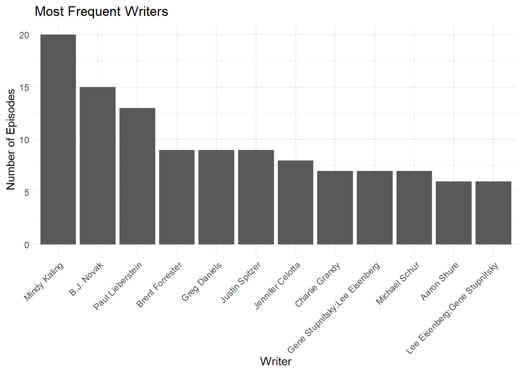

```r
ggplot(episodes_per_writer %>% filter(count_writer > 5)) +
  geom_bar(aes(reorder(writer, -count_writer), count_writer),
           alpha = 1, stat="identity") +
  labs(title="Most Frequent Writers") +
  labs(x="Writer", y="Number of Episodes") +
  theme_minimal() +
  theme(axis.text.x = element_text(angle = 45, hjust = 1))
```

Who wrote the highest rated episodes?

```r
rating_per_writer <-
  office_data %>%
  group_by(writer) %>%
  summarise_at(vars(imdb_rating), mean)
```

The Greg Daniels & Mindy Kaling team has the highest average rating

[figure not shown]

```r
ggplot(rating_per_writer %>% filter(imdb_rating > 8.5)) +
  geom_bar(aes(reorder(writer, -imdb_rating), imdb_rating),
           alpha = 1, stat="identity") +
  labs(title="Highest Rated Writers") +
  labs(x="Writer", y="IMDB Rating") +
  theme_minimal() +
  theme(axis.text.x = element_text(angle = 45, hjust = 1))
```

Which directors have the highest rating?

```r
rating_per_director <-
  office_data %>%
  group_by(director) %>%
  summarise_at(vars(imdb_rating), mean)
```

Harold Rarris and Steve Carell have the highest average rating per episode

[figure not shown]

```r
ggplot(rating_per_director %>% filter(imdb_rating > 8.5)) +
  geom_bar(aes(reorder(director, -imdb_rating), imdb_rating),
           alpha = 1, stat="identity") +
  labs(title="Highest Rated Directors") +
  labs(x="Writer", y="IMDB Rating") +
  theme_minimal() +
  theme(axis.text.x = element_text(angle = 45, hjust = 1))
```

Which writer and director combo get the highest rating?

```r
office_data$director_and_writer <- paste(office_data$director, office_data$writer, sep = "&")

rating_per_dir_and_writer <-
  office_data %>%
  group_by(director_and_writer) %>%
  summarise_at(vars(imdb_rating), mean)
```

Greg Daniels and Steve Carell are the dream team

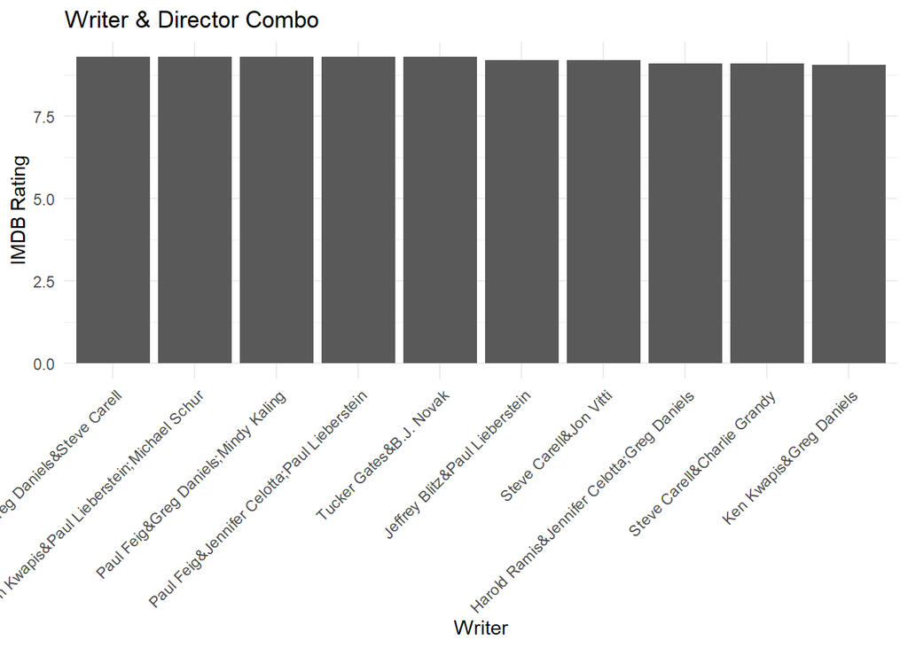

```r
ggplot(rating_per_dir_and_writer %>% filter(imdb_rating > 9)) +
  geom_bar(aes(reorder(director_and_writer, -imdb_rating), imdb_rating),
           alpha = 1, stat="identity") +
  labs(title="Writer & Director Combo") +
  labs(x="Writer", y="IMDB Rating") +
  theme_minimal() +
  theme(axis.text.x = element_text(angle = 45, hjust = 1))
```

How many episodes did Greg and Steve write and direct together?

```r
office_data %>%
  filter(director == 'Greg Daniels') %>%
  filter(writer == 'Steve Carell') %>%
  nrow()
```

```
## [1] 1
```

Only one, probably the finale…

```r
office_data %>%
  filter(director == 'Greg Daniels') %>%
  filter(writer == 'Steve Carell')
```

```
##   season_episode season.x episode.x episode_name     director       writer
## 1           2 22        2        22 Casino Night Greg Daniels Steve Carell
##   counter episode_reorder season.y episode.y        title imdb_rating
## 1       1              22        2        22 Casino Night         9.3
##   total_votes   air_date       director_and_writer
## 1        3644 2006-05-11 Greg Daniels&Steve Carell
```

Not the finale! Casino night, not surprising in hindsight

Who were the best writer director pairs over time? For more than one episode?

```r
episodes_per_writer_director <-
  office_data %>%
  group_by(director_and_writer) %>%
  mutate(count_director_and_writer = n()) %>%
  distinct()
```

The same director and group of writers don’t work together that often

```r
episodes_per_writer_director_filter <-
  episodes_per_writer_director %>%
  filter(count_director_and_writer > 2) %>%
  group_by(director_and_writer) %>%
  summarise_at(vars(imdb_rating), mean)
episodes_per_writer_director_filter
```

```
## # A tibble: 5 x 2
##   director_and_writer               imdb_rating
##   <chr>                                   <dbl>
## 1 Greg Daniels&Greg Daniels                8.4
## 2 Ken Kwapis&B.J. Novak                    8.3
## 3 Ken Kwapis&Greg Daniels                  9.07
## 4 Paul Lieberstein&Paul Lieberstein        8.03
## 5 Randall Einhorn&Mindy Kaling             8.30
```

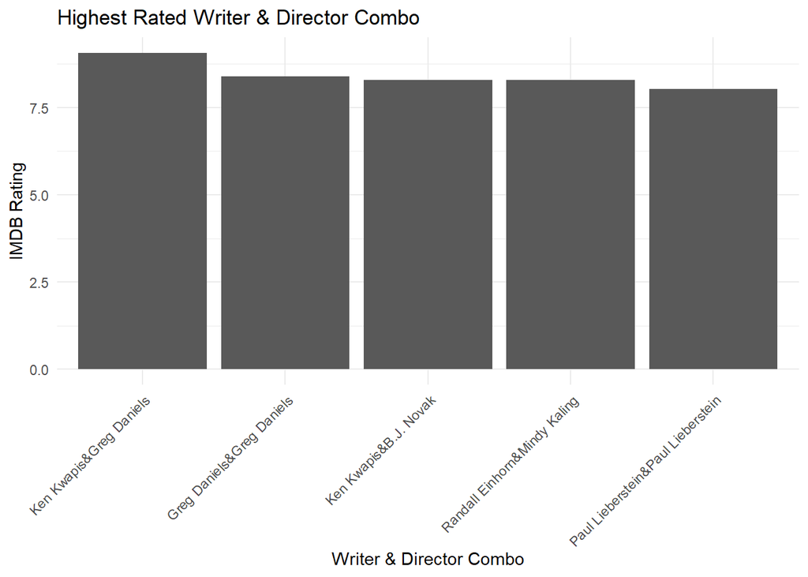

```r
ggplot(episodes_per_writer_director_filter) +
  geom_bar(aes(reorder(director_and_writer, -imdb_rating), imdb_rating),
           alpha = 1, stat="identity") +
  labs(title="Highest Rated Writer & Director Combo") +
  labs(x="Writer & Director Combo", y="IMDB Rating") +
  theme_minimal() +
  theme(axis.text.x = element_text(angle = 45, hjust = 1))
```

Who has the most lines?

```r
##Who has the most lines?
number_of_lines <-
  episode_text %>%
  select(character) %>%
  group_by(character) %>%
  mutate(num_lines = n()) %>%
  distinct()
```

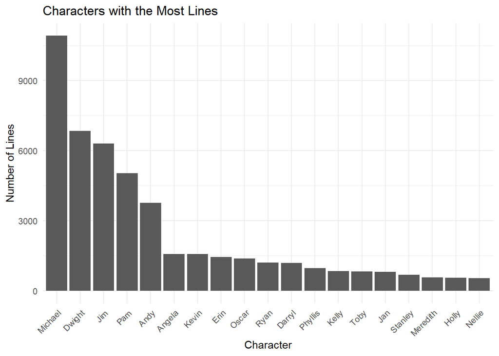

```r
ggplot(number_of_lines %>% filter(num_lines > 500)) +
  geom_bar(aes(reorder(character, -num_lines), num_lines),
           alpha=1, stat = 'identity') +
  labs(title="Characters with the Most Lines") +
  labs(x="Character", y="Number of Lines")  +
  theme_minimal() +
  theme(axis.text.x = element_text(angle = 45, hjust = 1))
```